# Blind Review Analysis

Francine Stephens

October 02, 2023

## Overview & Getting Started

The aim of this script is to:

- Provide the number of reviews posted to Intuit’s Blind page for the month.
- Provide a breakdown of the review postings by employment status (current vs. former).
- Report Intuit’s scores on key categories of employee experience and show trends over time and comparisons to competitors.
- Show month over month trends in key category scores to compare time trends

```r
knitr::opts_chunk$set(warning=FALSE, message=FALSE)

# Load Libraries
libraries <- c("tidyverse",
               "stringr",
               "lubridate",
               "ggplot2",
               "ggrepel",
               "gt",
               "htmltools",
               "paletteer",
               "scales",
               "sparkline"

)
lapply(libraries, require, character.only = TRUE)

## Set Paths
wd <- getwd()
output_path <- "/03-2022/"  #you want to write this to the monthly file
dir.create(file.path(wd, output_path))


# Set Key-Parameters
#### Dates ####
## Update the start of month date & start of next month date
month_start_reviews <- as.Date("2022-03-01")
col_month_start <- paste0("T", month_start_reviews)
month_start_next_month <- as.Date("2022-04-01")
month_previous_for_MOM_trend <- as.Date("2022-02-01")
col_month_prev <- paste0("T", month_previous_for_MOM_trend)
one_year_ago <- as.Date("2021-03-01")

#### Visual Elements ####
## Set the appropriate months for the line graphs
MoM_ratings_trend_graphs_title <- "Monthly Blind Ratings during the Last Year"
color_scheme_categories <- c("Career Growth" = "#003f5c",
     "Company Culture" = "#58508d",
     "Compensation/Benefits" = "#bc5090",
     "Management" = "#ff6361",
     "Work-Life Balance" = "#ffa600",
     "Overall" = "#686868")

# Set Key Functions
label_score_categories <- function(x) {
  x %>%
  mutate(Category = case_when(
    Category == "overall_rating" ~ "Overall",
    Category == "career_growth_rating" ~ "Career Growth",
    Category == "wlb_rating" ~ "Work-Life Balance",
    Category == "compensation_rating" ~ "Compensation/Benefits",
    Category == "company_culture_rating" ~ "Company Culture",
    Category == "management_rating" ~ "Management")
    )
  }

compute_MOM_trend_for_table <- function(x) {
  x %>%
  mutate(Change = Current - Previous) %>% # current month - last month
  select(Category, Rating = Current, Change)
}

dev.new(family = "Arial")
```

```r
## Import Data
temp_rds <- list.files(pattern="*.rds")
list2env(
  lapply(setNames(temp_rds, make.names(gsub("*.rds$", "", temp_rds))),
         readRDS), envir = .GlobalEnv)
```

## Overview of Data

View the chunk below and make sure that the current month falls in the **Date_Obj** field.

```r
summary(intuit_reviews)
```

```
##      date              Date_obj              Month             Day
##  Length:1037        Min.   :2020-05-28   Min.   : 1.000   Min.   : 1.00
##  Class :character   1st Qu.:2021-02-05   1st Qu.: 4.000   1st Qu.: 8.00
##  Mode  :character   Median :2021-09-17   Median : 6.000   Median :15.00
##                     Mean   :2021-09-24   Mean   : 6.487   Mean   :15.47
##                     3rd Qu.:2022-05-03   3rd Qu.: 9.000   3rd Qu.:23.00
##                     Max.   :2023-05-28   Max.   :12.000   Max.   :31.00
##       Year       emp_status         job_title         overall_rating
##  Min.   :2020   Length:1037        Length:1037        Min.   :1.000
##  1st Qu.:2021   Class :character   Class :character   1st Qu.:3.000
##  Median :2021   Mode  :character   Mode  :character   Median :4.000
##  Mean   :2021                                         Mean   :3.857
##  3rd Qu.:2022                                         3rd Qu.:5.000
##  Max.   :2023                                         Max.   :5.000
##  career_growth_rating   wlb_rating    compensation_rating
##  Min.   :1.000        Min.   :1.000   Min.   :1.000
##  1st Qu.:3.000        1st Qu.:4.000   1st Qu.:3.000
##  Median :3.000        Median :4.000   Median :4.000
##  Mean   :3.425        Mean   :4.095   Mean   :3.726
##  3rd Qu.:4.000        3rd Qu.:5.000   3rd Qu.:4.000
##  Max.   :5.000        Max.   :5.000   Max.   :5.000
##  company_culture_rating management_rating    title
##  Min.   :1.000          Min.   :1.000     Length:1037
##  1st Qu.:3.000          1st Qu.:3.000     Class :character
##  Median :4.000          Median :3.000     Mode  :character
##  Mean   :3.818          Mean   :3.266
##  3rd Qu.:5.000          3rd Qu.:4.000
##  Max.   :5.000          Max.   :5.000
```

## Former vs Current Employees

Check to see what is the breakdown for employment status in this month’s reviews. You will need to specify this on the slides (e.g., reviews from # of current employees).

```r
knitr::kable(intuit_reviews %>%
  filter(Month == month(month_start_reviews) & Year == year(month_start_reviews)) %>%
  group_by(emp_status) %>%
  count() %>%
  ungroup() %>%
  mutate(`%` = round((n/sum(n)) * 100, digits =0)) %>%
    rename(`Employment Status` = "emp_status")
)
```

| Employment Status | n | % |
| --- | --- | --- |
| Current Employee | 34 | 100 |

## Calculate Time Trends

Calculate 1-Year MoM ratings trends and output the graph that goes on the second slide in the series of Blind slides.

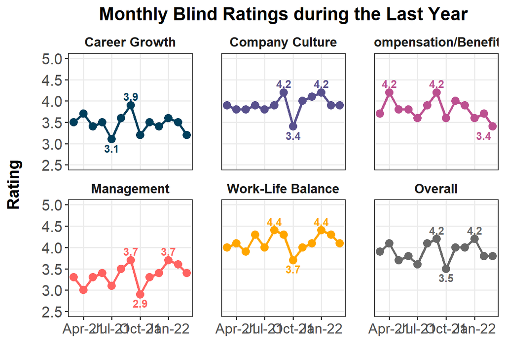

```r
ratings_over_time <- intuit_reviews %>%
  filter(Date_obj >= one_year_ago & Date_obj < month_start_next_month) %>%
  select(Month,
         Year,
         overall_rating,
         career_growth_rating,
         wlb_rating,
         compensation_rating,
         company_culture_rating,
         management_rating) %>%
  group_by(Month, Year) %>%
  summarize(across(ends_with("_rating"), ~mean(.x, na.rm = TRUE))
            ) %>%
  ungroup() %>%
  mutate(across(ends_with("_rating"), ~round(.x, digits = 1))
         ) %>%
  mutate(Month = as.character(Month),
         Month = str_pad(Month,
                         width = 2,
                         side = "left"),
         Year = as.character(Year),
         Year_Month = str_c(Year, Month, sep = "-"),
         Time = ym(Year_Month))

MoM_ratings_year <- ratings_over_time %>%
  select(Time,
         overall_rating,
         career_growth_rating,
         wlb_rating,
         compensation_rating,
         company_culture_rating,
         management_rating) %>%
  pivot_longer(cols = ends_with("_rating"),
               names_to = "Category",
               values_to = "Average Rating"
               ) %>%
  filter(Time >= one_year_ago) %>%
  label_score_categories()

ggplot(MoM_ratings_year,
       aes(x = Time, y = `Average Rating`, color = Category)
       ) +
  geom_line(size = 1.2) +
  geom_point(size = 3.5) +
  geom_text_repel(data = . %>%
               group_by(Category) %>%
               filter(`Average Rating` == max(`Average Rating`)),
             aes(label = sprintf('%0.1f', `Average Rating`), color = Category),
             show.legend = FALSE,
             fontface = "bold",
             nudge_y = 0.15,
             segment.color = NA
             ) +
  geom_text_repel(data = . %>%
               group_by(Category) %>%
               filter(`Average Rating` == min(`Average Rating`)),
             aes(label = sprintf('%0.1f', `Average Rating`), color = Category),
             show.legend = FALSE,
             fontface = "bold",
             nudge_y = -0.15,
             segment.color = NA) +
  labs(x = "",
       y = "Rating",
       title = MoM_ratings_trend_graphs_title) +
  scale_color_manual(values = color_scheme_categories) +
  scale_fill_manual(values = color_scheme_categories) +
  scale_x_date(date_labels = "%b-%y") +
  scale_y_continuous(limits = c(2.5, 5)) +
  facet_wrap(~ factor(Category, levels = c("Career Growth",
                                           "Company Culture",
                                           "Compensation/Benefits",
                                           "Management",
                                           "Work-Life Balance",
                                           "Overall"))
             ) +
  theme_bw(base_size = 13) +
  theme(text = element_text(family = "Arial"),
        panel.grid.minor.y = element_blank(),
        panel.spacing.x = unit(2, "lines"),
        panel.grid.minor.x = element_blank(),
        legend.position = "none",
        legend.title = element_blank(),
        plot.title = element_text(size = 18, face = "bold", hjust = 0.5),
        axis.title.x = element_text(size = 16, face = "bold"),
        axis.title.y = element_text(size = 16, face = "bold",
                                    margin = margin(t = 0, r = 20, b = 0, l = 0)
                                    ),
        axis.text.x = element_text(size = 14),
        axis.text.y = element_text(size = 15),
        strip.text = element_text(face = "bold", size = 13),
        strip.background = element_rect(fill = "white", color = "transparent")
)
```

```r
ggsave(path = paste0(wd, output_path),
       filename = "Ratings_Change_Over_Time.png",
       width = 15)
```

## Build Ratings Table

**Compute Last Month’s Ratings for Competitors**

```r
capture_competitors_monthly_ratings <- function(x, company) {
  x %>%
  filter(Date_obj >= month_start_reviews &
         Date_obj < month_start_next_month
         ) %>%
  summarize(across(ends_with("_rating"), ~mean(.x, na.rm=TRUE))) %>%
   pivot_longer(cols = ends_with("_rating"),
               names_to = "Category",
               values_to = company
               )
  }

amazon_ratings_last_month <- capture_competitors_monthly_ratings(
  amazon, "Amazon")

salesforce_ratings_last_month <- capture_competitors_monthly_ratings(
  salesforce, "Salesforce")

google_ratings_last_month <- capture_competitors_monthly_ratings(
  google, "Google")

facebook_ratings_last_month <- capture_competitors_monthly_ratings(
  facebook, "Facebook")

microsoft_ratings_last_month <- capture_competitors_monthly_ratings(
  microsoft, "Microsoft")

competitors_list <- list(google_ratings_last_month,
                         facebook_ratings_last_month,
                         amazon_ratings_last_month,
                         microsoft_ratings_last_month,
                         salesforce_ratings_last_month
                         )

competitors_ratings <- competitors_list %>%
  reduce(inner_join, by= "Category")  %>%
  mutate(across(where(is.numeric), ~round(.x, digits = 1))) %>%
  label_score_categories()

knitr::kable(competitors_ratings,
             caption = "Summary of Last Month's Ratings for Competitors")
```

Summary of Last Month’s Ratings for Competitors

| Category | Google | Facebook | Amazon | Microsoft | Salesforce |
| --- | --- | --- | --- | --- | --- |
| Overall | 4.3 | 3.8 | 3.5 | 4.0 | 3.9 |
| Career Growth | 3.5 | 4.0 | 3.6 | 3.5 | 3.5 |
| Work-Life Balance | 4.5 | 3.3 | 2.9 | 4.2 | 4.4 |
| Compensation/Benefits | 4.0 | 4.1 | 3.1 | 3.0 | 3.6 |
| Company Culture | 4.3 | 3.5 | 3.0 | 4.1 | 4.2 |
| Management | 3.8 | 3.3 | 3.1 | 3.7 | 3.5 |

**Pairwise T-Tests to compare Intuit’s scores to Competitors**

Compute t-test comparisons for context. We are still working out whether to use hypothesis tests on these data.

- If Intuit reviews are low for month then do not include in deck.
- If Intuit reviews > 30 then consider using, but include note on review counts in deck.

```r
ratings_ttest %>%
  filter(p.adj.signif != "ns") %>%
  group_by(Category) %>%
  summarize(sig_competitors = paste0(group2, collapse = ", ")
            ) %>%
  ungroup()
```

```
## # A tibble: 5 × 2
##   Category              sig_competitors
##   <chr>                 <chr>
## 1 Career Growth         Facebook, Microsoft
## 2 Company Culture       Amazon
## 3 Compensation/Benefits Facebook, Google, Microsoft
## 4 Overall               Google
## 5 Work-Life Balance     Amazon, Facebook, Microsoft
```

```r
# Identify Significant differences in table
extract_competitors_sig_diff <- function(category) {
  ratings_ttest %>%
  filter(p.adj.signif != "ns" & Category == category) %>%
  mutate(group2 = paste0("mean_", group2)) %>%
  pull(group2)
  }
career_growth_sig <- extract_competitors_sig_diff("Career Growth")

company_culture_sig <- extract_competitors_sig_diff("Company Culture")

compensation_sig <- extract_competitors_sig_diff("Compensation/Benefits")

work_life_balance_sig <- extract_competitors_sig_diff("Work-Life Balance")

overall_sig <- extract_competitors_sig_diff("Overall")

# Label Table with Company Name & Sample Size
intuit_title <- ratings_ttest %>%
  distinct(n1) %>%
  mutate(n1 = paste0("Intuit (N = ", n1, ")")) %>%
  pull()

title_naming_competitors <- function(company) {
  ratings_ttest %>%
  filter(group2 == company) %>%
  distinct(n2) %>%
  mutate(n2 = paste0(company, " (N = ", n2, ")")) %>%
  pull()
}
amazon_title <- title_naming_competitors("Amazon")
facebook_title <- title_naming_competitors("Facebook")
google_title <- title_naming_competitors("Google")
microsoft_title <- title_naming_competitors("Microsoft")
salesforce_title <- title_naming_competitors("Salesforce")


summary_stats_by_category_company %>%
  pivot_wider(names_from = "Company",
              values_from = c(n, mean, sd)
              ) %>%
  relocate(ends_with("_Intuit"), .after = "Category") %>%
  gt() %>%
  tab_style(style = list(
            cell_text(weight = "bold")

          ),
          locations = cells_body(
            columns = one_of(career_growth_sig),

            rows = Category == "Career Growth"
          )
        ) %>%
   tab_style(style = list(
            cell_text(weight = "bold")

          ),
          locations = cells_body(
            columns = one_of(company_culture_sig),

            rows = Category == "Company Culture"
          )
        ) %>%
   tab_style(style = list(
            cell_text(weight = "bold")

          ),
          locations = cells_body(
            columns = one_of(compensation_sig),

            rows = Category == "Compensation/Benefits"
          )
        ) %>%
  tab_style(style = list(
            cell_text(weight = "bold")

          ),
          locations = cells_body(
            columns = one_of(work_life_balance_sig),

            rows = Category == "Work-Life Balance"
          )
        ) %>%
  tab_style(style = list(
            cell_text(weight = "bold")

          ),
          locations = cells_body(
            columns = one_of(overall_sig),

            rows = Category == "Overall"
          )
        ) %>%
  tab_style(style = list(
            cell_fill(color = "#D3D3D3")

          ),
          locations = cells_body(
            columns = ends_with("_Intuit"),
            rows = everything()
          )
        ) %>%
  tab_style(
    style = cell_borders(
      sides = "right",
      color = "black",
      weight = px(1.5),
      style = "solid"
    ),
    locations = cells_body(
      columns = ends_with("SD_Intuit"),
      rows = everything()
    )
  ) %>%
  tab_style(
    style = cell_borders(
      sides = "left",
      color = "black",
      weight = px(1.5),
      style = "solid"
      ),
    locations = cells_body(
    columns = ends_with("Mean_Intuit"),
    rows = everything()
  )) %>%
  tab_spanner(ends_with("Intuit"), label = intuit_title) %>%
  tab_spanner(ends_with("Amazon"), label = amazon_title) %>%
  tab_spanner(ends_with("Facebook"), label = facebook_title) %>%
  tab_spanner(ends_with("Google"), label = google_title) %>%
  tab_spanner(ends_with("Microsoft"), label = microsoft_title) %>%
  tab_spanner(ends_with("Salesforce"), label = salesforce_title) %>%
  cols_hide(starts_with("n_")) %>%
  cols_label(
    starts_with("n_") ~ "N",
    starts_with("mean_") ~ "Mean",
    starts_with("sd_") ~ "SD"
  )
```

[output not shown]

**Export pairwise comparison t-test as csv files**

```r
write_csv(ratings_ttest,
          paste0(wd, output_path, "ratings_ttest.csv"))

write_csv(summary_stats_by_category_company,
          paste0(wd, output_path, "ratings_summary_stats.csv"))
```

**Compute Intuit’s MoM Trend by Rating Category**

```r
vs_last_month_by_category <- ratings_over_time %>%
         filter(Time >= month_previous_for_MOM_trend) %>%
  select(Time,
         overall_rating,
         career_growth_rating,
         wlb_rating,
         compensation_rating,
         company_culture_rating,
         management_rating) %>%
  pivot_longer(cols = ends_with("_rating"),
               names_to = "Category",
               values_to = "Average Rating"
               ) %>%
  mutate(Time = paste0("T", Time),
         Time = ifelse(Time == col_month_start, "Current", "Previous")
         ) %>%
  pivot_wider(id_cols = Category,
              names_from = Time,
              values_from = `Average Rating`) %>%
  compute_MOM_trend_for_table() %>%
  label_score_categories() %>%
  select(Category, Change)

data_for_table <- intuit_reviews %>%
  filter(Date_obj >= month_start_reviews &
           Date_obj < month_start_next_month) %>%
  select(
         overall_rating,
         career_growth_rating,
         wlb_rating,
         compensation_rating,
         company_culture_rating,
         management_rating) %>%
  summarize(across(ends_with("_rating"), ~mean(.x, na.rm = TRUE))
            ) %>%
  ungroup() %>%
  mutate(across(ends_with("_rating"), ~round(.x, digits = 1))) %>%
  pivot_longer(cols = ends_with("_rating"),
               names_to = "Category",
               values_to = "Rating"
               ) %>%
  label_score_categories() %>%
  left_join(., vs_last_month_by_category, by = "Category") %>%
  left_join(., competitors_ratings, by = "Category") %>%
  mutate(Google = Rating - Google,
         Facebook = Rating - Facebook,
         Amazon = Rating - Amazon,
         Microsoft = Rating - Microsoft,
         Salesforce = Rating - Salesforce) %>%
  mutate(across(c(Google:Salesforce), ~round(.x, digits = 1)))
```

**Create Sparkline One Year Trend**

```r
## Create Sparkline Data for Table:
last_year_month_month_ratings <- ratings_over_time %>%
  select(Time,
         overall_rating,
         career_growth_rating,
         wlb_rating,
         compensation_rating,
         company_culture_rating,
         management_rating) %>%
  pivot_longer(cols = ends_with("_rating"),
               names_to = "Category",
               values_to = "Average Rating"
               ) %>%
  filter(Time >= one_year_ago &
                  Time < month_start_next_month) %>%
  label_score_categories() %>%
    arrange(Time) %>%
    rename(Rating = `Average Rating`)

plot_spark <- function(data){
  data %>%
    ggplot(aes(x = Time, y = Rating), color = "grey") +
    geom_line(size = 15) +
    theme_void() +
    scale_color_identity() +
    theme(legend.position = "none")
}

# Add SPARKLINE column to data
Ratings_plots <- last_year_month_month_ratings %>%
  nest(Ratings = c(Time, Rating)) %>%
  mutate(plot = map(Ratings, plot_spark)) %>%
  select(-Ratings)

data_for_table <- data_for_table %>%
  left_join(., Ratings_plots, by = "Category") %>%
  relocate(plot, .after = "Change")

gt_spark <- function(table_data, plot_col, data_col){
  # save the data extract ahead of time
  # to be used in our anonymous function below
  data_in = pluck(table_data, "_data", data_col)

  text_transform(
    table_data,
    # note the use of {{}} here - this is tidy eval
    # that allows you to indicate specific columns
    locations = cells_body(columns = vars({{plot_col}})),
    fn = function(x){
      sparkline_plot <- map(
        data_in,
        ~spk_chr(values = .x, chartRangeMin = 0)
        )

      map(sparkline_plot, gt::html)
    }
  )
}
```

**Create competitor buttons**

```r
## Color & Style buttons based on Intuit's scores relative to competitors
add_button_color_style <- function(company){
      add_color <- if (company == 0) {
        "background: hsl(90, 0%, 81%); color: hsl(180, 0%, 25%);"
      } else if (company > 0) {
        "background: hsl(230, 70%, 90%); color: hsl(230, 45%, 30%);"
      } else if (company < 0) {
        "background: hsl(350, 70%, 90%); color: hsl(350, 45%, 30%);"
      }
      div_out <- htmltools::div(
        style = paste(
          "display: inline-block; padding: 2px 12px; border-radius: 15px; font-weight: 600; font-size: 12px;",
          add_color
          ),
        paste(company)
      )

      as.character(div_out) %>%
        gt::html()
}
```

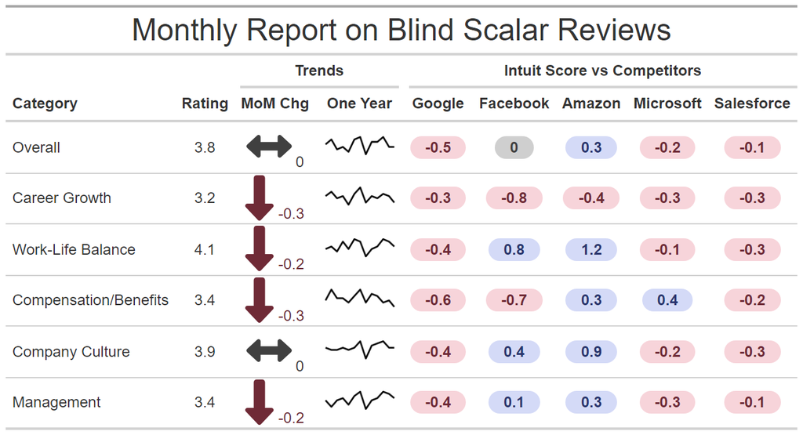

```r
# Build and Export Table
data_for_table_styled <- data_for_table %>%
  mutate(Google = map(Google, add_button_color_style),
         Facebook = map(Facebook, add_button_color_style),
         Amazon = map(Amazon, add_button_color_style),
         Microsoft = map(Microsoft, add_button_color_style),
         Salesforce = map(Salesforce, add_button_color_style)
         )

gt(data_for_table_styled) %>%
    tab_header(
    title = md("Monthly Report on Blind Scalar Reviews")
  ) %>%
    tab_spanner(Change:plot, label = "Trends") %>%
    tab_spanner(Google:Salesforce, label = "Intuit Score vs Competitors") %>%
  text_transform(
    locations = cells_body(columns = c(Change)),
    fn = function(x){

      Change <- as.numeric(x)

      choose_logo <-function(x){
if (x >= 0.1){
          gt::html(fontawesome::fa("long-arrow-alt-up", fill = "#2a366f", height = "3em"),
                                   glue::glue("<span style='color:#2a366f;font-face:bold;font-size:12px;text-align:center;'>{x}</span>"))
        } else if (x <= -0.1){
          gt::html(fontawesome::fa("long-arrow-alt-down", fill = "#6f2a36", height = "3em"), glue::glue("<span style='color:#6f2a36;font-face:bold;font-size:12px;text-align:center;'>{x}</span>"))
        } else {
          gt::html(fontawesome::fa("arrows-alt-h", fill = "#404040", height = "3em"), glue::glue("<span style='color:#404040;font-face:bold;font-size:12px;text-align:center;'>{x}</span>"))
        }
        }

      map(Change, choose_logo)

    }
  ) %>%
  text_transform(
    locations = cells_body(c(plot)),
    fn = function(x){
      map(Ratings_plots$plot, ggplot_image, height = px(15), aspect_ratio = 4)
    }
  ) %>%
  cols_label(
    Change = "MoM Chg",
    plot = "One Year"
             ) %>%
  cols_align(
    align = c("center"),
    columns = c(Rating, Change, Google, Facebook, Amazon, Microsoft, Salesforce)
  ) %>%
  tab_options(
    table.font.names = "Arial",
    heading.title.font.size = 24,
    heading.subtitle.font.size = 14,
    column_labels.font.weight = 'bold',
    table.font.size = 12,
    data_row.padding = px(1),
    table.border.bottom.color = "white"
  ) %>%
  gtsave(filename = "blind table.png",
         path = paste0(wd, output_path))
```